# Session_3-AnalysingData

# 5 Cumulative Logit Link Models

These models work perfectly with rating data. Ratings are inherently ordered, 1, 2, … n, and expect to observe an increase (or decrease) in overall ratings from 1 to n. To demonstrate this, we will use an example using the package “ordinal”. Data were from a rating experiment where six participants rated the percept of nasality in the production of particular consonants in Arabic. The data came from nine producing subjects. The ratings were from 1 to 5. This example can apply to any study, e.g., rating grammaticality of sentences, rating how positive the sentiments are in a article, interview responses, etc.

## 5.1 Importing and pre-processing

We start by importing the data and process it. We change the reference level in the predictor

```r
rating <- read_csv("rating.csv")
rating
```

| X1 | Response | Context | Subject | Item | Rater |
| --- | --- | --- | --- | --- | --- |
| 406 | 2 | n-3 | p04 | noo3-w | R01 |
| 407 | 4 | isolation | p04 | noo3-v | R01 |
| 408 | 2 | o-3 | p04 | djuu3-w | R01 |
| 409 | 4 | isolation | p04 | djuu3-v | R01 |
| 410 | 3 | n-7 | p04 | nuu7-w | R01 |
| 411 | 3 | isolation | p04 | nuu7-v | R01 |
| 412 | 1 | 3--3 | p04 | 3oo3-w | R01 |
| 413 | 2 | isolation | p04 | 3oo3-v | R01 |
| 414 | 2 | o-7 | p04 | loo7-w | R01 |
| 415 | 1 | o-3 | p04 | bii3-w | R01 |

[output cut: 395 more lines]

```r
rating <- rating %>%
  mutate(Response = factor(Response),
         Context = factor(Context)) %>%
  mutate(Context = relevel(Context, "isolation"))
rating
```

| X1 | Response | Context | Subject | Item | Rater |
| --- | --- | --- | --- | --- | --- |
| 406 | 2 | n-3 | p04 | noo3-w | R01 |
| 407 | 4 | isolation | p04 | noo3-v | R01 |
| 408 | 2 | o-3 | p04 | djuu3-w | R01 |
| 409 | 4 | isolation | p04 | djuu3-v | R01 |
| 410 | 3 | n-7 | p04 | nuu7-w | R01 |
| 411 | 3 | isolation | p04 | nuu7-v | R01 |
| 412 | 1 | 3--3 | p04 | 3oo3-w | R01 |
| 413 | 2 | isolation | p04 | 3oo3-v | R01 |
| 414 | 2 | o-7 | p04 | loo7-w | R01 |
| 415 | 1 | o-3 | p04 | bii3-w | R01 |

[output cut: 395 more lines]

## 5.2 Our first model

We run our first clm model as a simple, i.e., with no random effects

```r
mdl.clm <- rating %>%
  clm(Response ~ Context, data = .)
summary(mdl.clm)
```

```
formula: Response ~ Context
data:    .
```

| link | threshold | nobs | logLik | AIC | niter | max.grad | cond.H |
| --- | --- | --- | --- | --- | --- | --- | --- |
| logit | flexible | 405 | -526.16 | 1086.31 | 5(0) | 3.61e-09 | 1.3e+02 |

```
Coefficients:
            Estimate Std. Error z value Pr(>|z|)
Context3--3  -0.1384     0.5848  -0.237   0.8130
Context3-n    3.5876     0.4721   7.600 2.96e-14 ***
Context3-o   -0.4977     0.3859  -1.290   0.1971
Context7-n    2.3271     0.5079   4.582 4.60e-06 ***
Context7-o    0.2904     0.4002   0.726   0.4680
Contextn-3    2.8957     0.6685   4.331 1.48e-05 ***
Contextn-7    2.2678     0.4978   4.556 5.22e-06 ***
Contextn-n    2.8697     0.4317   6.647 2.99e-11 ***
Contextn-o    3.5152     0.4397   7.994 1.30e-15 ***
Contexto-3   -0.2540     0.4017  -0.632   0.5272
Contexto-7   -0.6978     0.3769  -1.851   0.0641 .
Contexto-n    2.9640     0.4159   7.126 1.03e-12 ***
Contexto-o   -0.6147     0.3934  -1.562   0.1182
---
Signif. codes:  0 ‘***’ 0.001 ‘**’ 0.01 ‘*’ 0.05 ‘.’ 0.1 ‘ ’ 1

Threshold coefficients:
    Estimate Std. Error z value
1|2  -1.4615     0.2065  -7.077
2|3   0.4843     0.1824   2.655
3|4   1.5492     0.2044   7.578
4|5   3.1817     0.2632  12.089
```

## 5.3 Testing significance

We can evaluate whether “Context” improves the model fit, by comparing a null model with our model. Of course “Context” is improving the model fit.

```r
mdl.clm.Null <- rating %>%
  clm(Response ~ 1, data = .)
anova(mdl.clm, mdl.clm.Null)
```

```
Likelihood ratio tests of cumulative link models:
```

|  | formula: | link: | threshold: |
| --- | --- | --- | --- |
| mdl.clm.Null | Response ~ 1 | logit | flexible |
| mdl.clm | Response ~ Context | logit | flexible |

```
             no.par    AIC  logLik LR.stat df Pr(>Chisq)
mdl.clm.Null      4 1281.1 -636.56
mdl.clm          17 1086.3 -526.16   220.8 13  < 2.2e-16 ***
---
Signif. codes:  0 ‘***’ 0.001 ‘**’ 0.01 ‘*’ 0.05 ‘.’ 0.1 ‘ ’ 1
```

## 5.4 Interpreting a cumulative model

As a way to interpret the model, we can look at the coefficients and make sense of the results. A CLM model is a Logistic model with a cumulative effect. The “Coefficients” are the estimates for each level of the fixed effect; the “Threshold coefficients” are those of the response. For the former, a negative coefficient indicates a negative association with the response; and a positive is positively associated with the response. The p values are indicating the significance of each level. For the “Threshold coefficients”, we can see the cumulative effects of ratings 1|2, 2|3, 3|4 and 4|5 which indicate an overall increase in the ratings from 1 to 5.

## 5.5 Plotting

We use a modified version of a plotting function that allows us to visualise the effects. For this, we use the base R plotting functions

```r
par(oma=c(1, 0, 0, 3),mgp=c(2, 1, 0))
xlimNas = c(min(mdl.clm$beta), max(mdl.clm$beta))
ylimNas = c(0,1)
plot(0,0,xlim=xlimNas, ylim=ylimNas, type="n", ylab=expression(Probability), xlab="", xaxt = "n",main="Predicted curves - Nasalisation",cex=2,cex.lab=1.5,cex.main=1.5,cex.axis=1.5)
axis(side = 1, at = c(0,mdl.clm$beta),labels = levels(rating$Context), las=2,cex=2,cex.lab=1.5,cex.axis=1.5)
```

```r
xsNas = seq(xlimNas[1], xlimNas[2], length.out=100)
lines(xsNas, plogis(mdl.clm$Theta[1] - xsNas), col='black')
lines(xsNas, plogis(mdl.clm$Theta[2] - xsNas)-plogis(mdl.clm$Theta[1] - xsNas), col='red')
```

```r
lines(xsNas, plogis(mdl.clm$Theta[3] - xsNas)-plogis(mdl.clm$Theta[2] - xsNas), col='green')
lines(xsNas, plogis(mdl.clm$Theta[4] - xsNas)-plogis(mdl.clm$Theta[3] - xsNas), col='orange')
```

```r
lines(xsNas, 1-(plogis(mdl.clm$Theta[4] - xsNas)), col='blue')
abline(v=c(0,mdl.clm$beta),lty=3)
```

```r
abline(h=0, lty="dashed")
abline(h=1, lty="dashed")
```

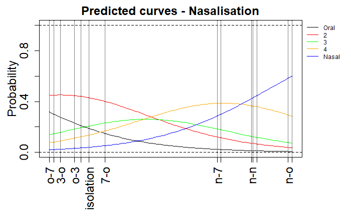

```r
legend(par('usr')[2], par('usr')[4], bty='n', xpd=NA,lty=1, col=c("black", "red", "green", "orange", "blue"),
       legend=c("Oral", "2", "3", "4", "Nasal"),cex=0.75)
```

# 6 Linear Mixed-effects Models. Why random effects matter

Let’s generate a new dataframe that we will use later on for our mixed models

```r
## Courtesy of Bodo Winter
set.seed(666)
#we create 6 subjects
subjects <- paste0('S', 1:6)
#here we add repetitions within speakers
subjects <- rep(subjects, each = 20)
items <- paste0('Item', 1:20)
#below repeats
items <- rep(items, 6)
#below is to generate random numbers that are log values
logFreq <- round(rexp(20)*5, 2)
#below we are repeating the logFreq 6 times to fit with the number of speakers and items
logFreq <- rep(logFreq, 6)
xdf <- data.frame(subjects, items, logFreq)
#below removes the individual variables we had created because they are already in the dataframe
rm(subjects, items, logFreq)

xdf$Intercept <- 300
submeans <- rep(rnorm(6, sd = 40), 20)
#sort make the means for each subject is the same...
submeans <- sort(submeans)
xdf$submeans <- submeans
#we create the same thing for items... we allow the items mean to vary between words...
itsmeans <- rep(rnorm(20, sd = 20), 6)
xdf$itsmeans <- itsmeans
xdf$error <- rnorm(120, sd = 20)
#here we create an effect column,
#here for each logFreq, we have a decrease of -5 of that particular logFreq
xdf$effect <- -5 * xdf$logFreq

xdf$dur <- xdf$Intercept + xdf$submeans + xdf$itsmeans + xdf$error + xdf$effect
#below is to subset the data and get only a few columns.. the -c(4:8) removes the columns 4 to 8..
xreal <- xdf[,-c(4:8)]
head(xreal)
```

|  | subjects | items | logFreq | dur |
| --- | --- | --- | --- | --- |
| 1 | S1 | Item1 | 2.74 | 312.4086 |
| 2 | S1 | Item2 | 9.82 | 236.5816 |
| 3 | S1 | Item3 | 0.70 | 364.6832 |
| 4 | S1 | Item4 | 0.05 | 243.3778 |
| 5 | S1 | Item5 | 2.76 | 302.8896 |
| 6 | S1 | Item6 | 17.57 | 196.5565 |

```r
rm(xdf, submeans, itsmeans)
```

## 6.1 Plots

Let’s start by doing a correlation test and plotting the data. Our results show that there is a negative correlation between duration and LogFrequency, and the plot shows this decrease.

```r
corrMixed <- as.matrix(xreal[-c(1:2)]) %>%
  rcorr(type="pearson")
print(corrMixed)
```

```
        logFreq   dur
logFreq    1.00 -0.54
dur       -0.54  1.00

n= 120


P
        logFreq dur
logFreq          0
dur      0
```

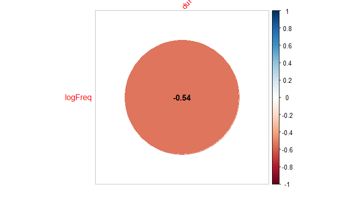

```r
corrplot(corrMixed$r, method = "circle", type = "upper", tl.srt = 45,
         addCoef.col = "black", diag = FALSE,
         p.mat = corrMixed$p, sig.level = 0.05)
```

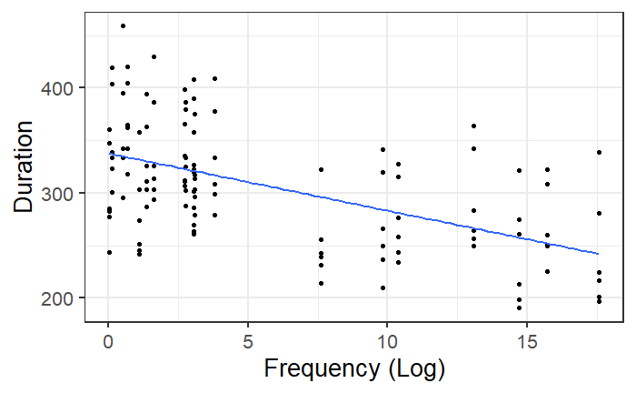

```r
ggplot.xreal <- xreal %>%
  ggplot(aes(x = logFreq, y = dur)) +
  geom_point()+ theme_bw(base_size = 20) +
  labs(y = "Duration", x = "Frequency (Log)") +
  geom_smooth(method = lm, se=F)
ggplot.xreal
```

## 6.2 Linear model

```r
mdl.lm.xreal <- xreal %>%
  lm(dur ~ logFreq, data = .)
summary(mdl.lm.xreal)
```

```
Call:
lm(formula = dur ~ logFreq, data = .)

Residuals:
    Min      1Q  Median      3Q     Max
-94.322 -35.465  -4.364  33.020 123.955

Coefficients:
            Estimate Std. Error t value Pr(>|t|)
(Intercept) 337.9730     6.2494  54.081  < 2e-16 ***
logFreq      -5.4601     0.7846  -6.959 2.06e-10 ***
---
Signif. codes:  0 ‘***’ 0.001 ‘**’ 0.01 ‘*’ 0.05 ‘.’ 0.1 ‘ ’ 1

Residual standard error: 48.29 on 118 degrees of freedom
Multiple R-squared:  0.291, Adjusted R-squared:  0.285
F-statistic: 48.43 on 1 and 118 DF,  p-value: 2.057e-10
```

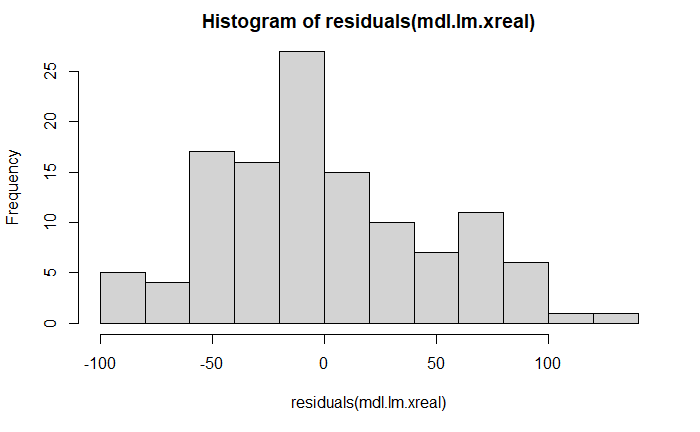

```r
hist(residuals(mdl.lm.xreal))
```

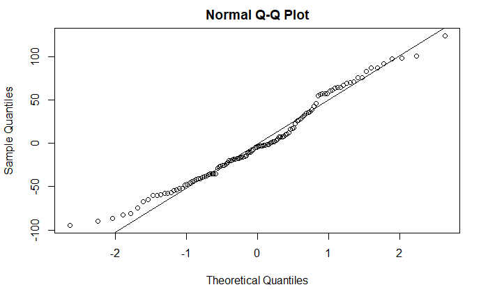

```r
qqnorm(residuals(mdl.lm.xreal)); qqline(residuals(mdl.lm.xreal))
```

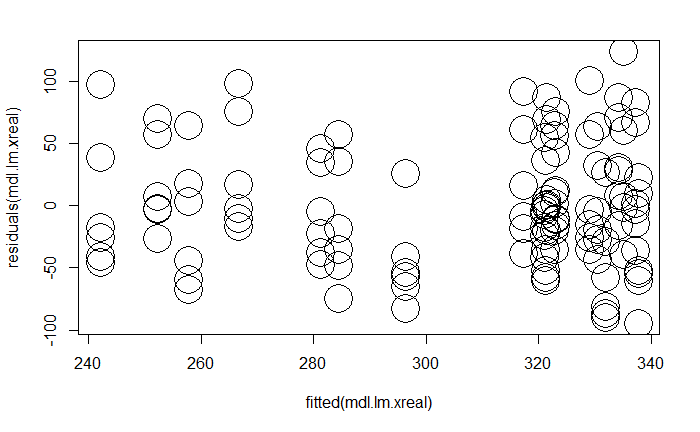

```r
plot(fitted(mdl.lm.xreal), residuals(mdl.lm.xreal), cex = 4)
```

## 6.3 Linear Mixed Model

Our Linear Mixed effects Model will take into account the random effects we added and also our model specifications. We use a Maximum Likelihood estimate (REML = FALSE) as this is what we will use for model comparison. The Linear Mixed Model is reflecting our model specifications The SD of our subjects is picked up correctly. The model results are “almost” the same as our linear model above. The coefficient for the “Intercept” is at 337.973 and the coefficient for LogFrequency is at -5.460. This indicates that for each unit of increase in the LogFrequency, there is a decrease by 5.460 (ms).

```r
mdl.lmer.xreal <- xreal %>%
  lmer(dur ~ logFreq  +(1|subjects) + (1|items), data = ., REML = FALSE)
summary(mdl.lmer.xreal)
```

```
Linear mixed model fit by maximum likelihood . t-tests use Satterthwaite's method [
lmerModLmerTest]
Formula: dur ~ logFreq + (1 | subjects) + (1 | items)
   Data: .

     AIC      BIC   logLik deviance df.resid
  1105.8   1119.8   -547.9   1095.8      115

Scaled residuals:
     Min       1Q   Median       3Q      Max
-2.06735 -0.60675  0.07184  0.61122  2.39854

Random effects:
 Groups   Name        Variance Std.Dev.
 items    (Intercept)  589.8   24.29
 subjects (Intercept) 1471.7   38.36
 Residual              284.0   16.85
Number of obs: 120, groups:  items, 20; subjects, 6

Fixed effects:
            Estimate Std. Error      df t value Pr(>|t|)
(Intercept)  337.973     17.587   9.126  19.218 1.08e-08 ***
logFreq       -5.460      1.004  19.215  -5.436 2.92e-05 ***
---
Signif. codes:  0 ‘***’ 0.001 ‘**’ 0.01 ‘*’ 0.05 ‘.’ 0.1 ‘ ’ 1

Correlation of Fixed Effects:
        (Intr)
logFreq -0.322
```

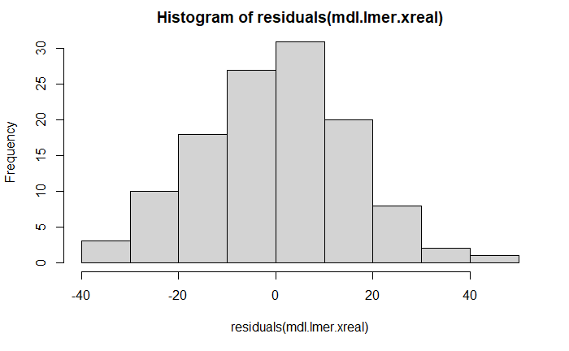

```r
hist(residuals(mdl.lmer.xreal))
```

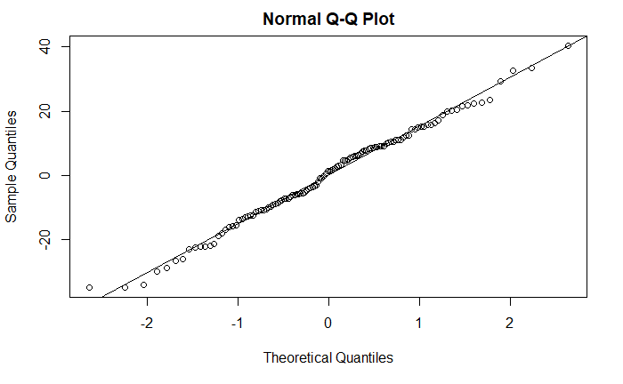

```r
qqnorm(residuals(mdl.lmer.xreal)); qqline(residuals(mdl.lmer.xreal))
```

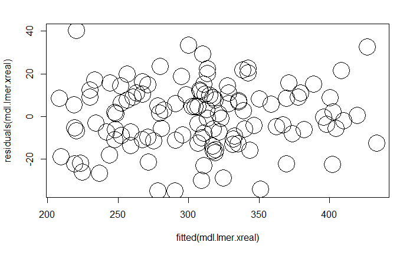

```r
plot(fitted(mdl.lmer.xreal), residuals(mdl.lmer.xreal), cex = 4)
```

## 6.4 Our second Mixed model

This second model add a by-subject random slope. Random slopes allow for the variation that exists in the random effects to be taken into account. An intercept only model provides an averaged values to our participants.

```r
mdl.lmer.xreal.2 <- xreal %>%
  lmer(dur ~ logFreq + (logFreq|subjects) + (1|items), data = ., REML = FALSE)
summary(mdl.lmer.xreal.2)
```

```
Linear mixed model fit by maximum likelihood . t-tests use Satterthwaite's method [
lmerModLmerTest]
Formula: dur ~ logFreq + (logFreq | subjects) + (1 | items)
   Data: .

     AIC      BIC   logLik deviance df.resid
  1109.5   1129.0   -547.7   1095.5      113

Scaled residuals:
     Min       1Q   Median       3Q      Max
-2.10907 -0.60681  0.06198  0.58272  2.45718

Random effects:
 Groups   Name        Variance  Std.Dev. Corr
 items    (Intercept) 5.892e+02 24.2736
 subjects (Intercept) 1.419e+03 37.6676
          logFreq     2.917e-02  0.1708  1.00
 Residual             2.827e+02 16.8144
Number of obs: 120, groups:  items, 20; subjects, 6

Fixed effects:
            Estimate Std. Error      df t value Pr(>|t|)
(Intercept)  337.973     17.332   8.882  19.500 1.35e-08 ***
logFreq       -5.460      1.006  19.384  -5.426 2.89e-05 ***
---
Signif. codes:  0 ‘***’ 0.001 ‘**’ 0.01 ‘*’ 0.05 ‘.’ 0.1 ‘ ’ 1

Correlation of Fixed Effects:
        (Intr)
logFreq -0.265
convergence code: 0
boundary (singular) fit: see ?isSingular
```

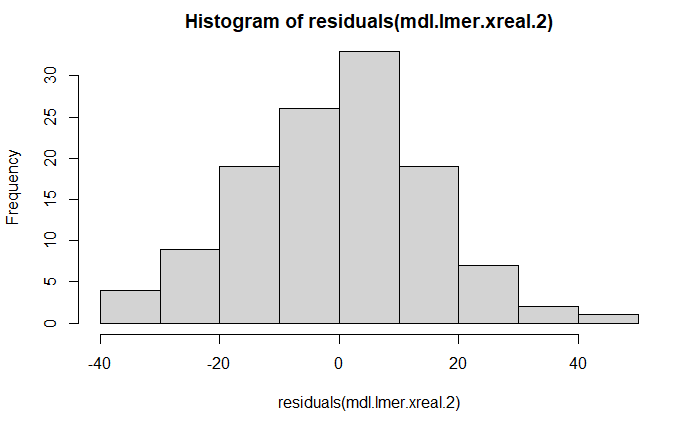

```r
hist(residuals(mdl.lmer.xreal.2))
```

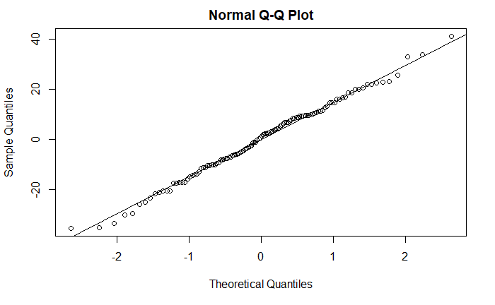

```r
qqnorm(residuals(mdl.lmer.xreal.2)); qqline(residuals(mdl.lmer.xreal.2))
```

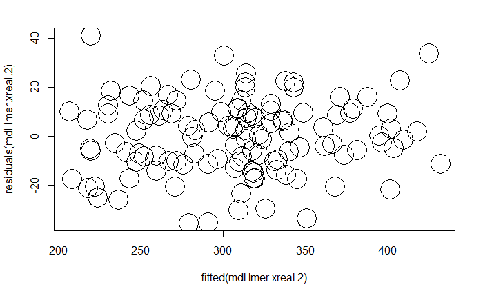

```r
plot(fitted(mdl.lmer.xreal.2), residuals(mdl.lmer.xreal.2), cex = 4)
```

## 6.5 Model comparison

But where are our p values? The lme4 developers decided not to include p values due to various issues with estimating df. What we can do instead is to compare models. We need to create a null model to allow for significance testing. As expected our predictor is significantly contributing to the difference.

```r
mdl.lmer.xreal.Null <- xreal %>%
  lmer(dur ~ 1 + (logFreq|subjects) + (1|items), data = ., REML = FALSE)
anova(mdl.lmer.xreal.Null, mdl.lmer.xreal.2)
```

```
Data: .
Models:
mdl.lmer.xreal.Null: dur ~ 1 + (logFreq | subjects) + (1 | items)
mdl.lmer.xreal.2: dur ~ logFreq + (logFreq | subjects) + (1 | items)
                    npar    AIC    BIC  logLik deviance  Chisq Df Pr(>Chisq)
mdl.lmer.xreal.Null    6 1125.4 1142.1 -556.68   1113.4
mdl.lmer.xreal.2       7 1109.5 1129.0 -547.73   1095.5 17.891  1  2.339e-05 ***
---
Signif. codes:  0 ‘***’ 0.001 ‘**’ 0.01 ‘*’ 0.05 ‘.’ 0.1 ‘ ’ 1
```

Also, do we really need random slopes? From the result below, we don’t seem to need random slopes at all, given that adding random slopes does not improve the model fit. I always recommend testing this. Most of the time I keep random slopes.

```r
anova(mdl.lmer.xreal, mdl.lmer.xreal.2)
```

```
Data: .
Models:
mdl.lmer.xreal: dur ~ logFreq + (1 | subjects) + (1 | items)
mdl.lmer.xreal.2: dur ~ logFreq + (logFreq | subjects) + (1 | items)
                 npar    AIC    BIC  logLik deviance  Chisq Df Pr(>Chisq)
mdl.lmer.xreal      5 1105.8 1119.8 -547.92   1095.8
mdl.lmer.xreal.2    7 1109.5 1129.0 -547.73   1095.5 0.3782  2     0.8277
```

But if you are really (really!!!) obsessed by p values, then you can also use lmerTest. BUT use after comparing models to evaluate contribution of predictors

```r
mdl.lmer.xreal.lmerTest <- xreal %>%
  lmer(dur ~ logFreq + (logFreq|subjects) + (1|items), data = ., REML = TRUE)
summary(mdl.lmer.xreal.lmerTest)
```

```
Linear mixed model fit by REML. t-tests use Satterthwaite's method ['lmerModLmerTest']
Formula: dur ~ logFreq + (logFreq | subjects) + (1 | items)
   Data: .

REML criterion at convergence: 1086.1

Scaled residuals:
     Min       1Q   Median       3Q      Max
-2.09668 -0.60121  0.06407  0.58451  2.46140

Random effects:
 Groups   Name        Variance  Std.Dev. Corr
 items    (Intercept) 6.284e+02 25.0682
 subjects (Intercept) 1.639e+03 40.4785
          logFreq     3.402e-02  0.1845  1.00
 Residual             2.831e+02 16.8244
Number of obs: 120, groups:  items, 20; subjects, 6

Fixed effects:
            Estimate Std. Error      df t value Pr(>|t|)
(Intercept)  337.973     18.465   7.494  18.303 1.72e-07 ***
logFreq       -5.460      1.037  18.180  -5.265 5.09e-05 ***
---
Signif. codes:  0 ‘***’ 0.001 ‘**’ 0.01 ‘*’ 0.05 ‘.’ 0.1 ‘ ’ 1

Correlation of Fixed Effects:
        (Intr)
logFreq -0.250
convergence code: 0
boundary (singular) fit: see ?isSingular
```

```r
detach("package:lmerTest", unload = TRUE)
```

## 6.6 Our final Mixed model

Our final model uses REML (or Restricted Maximum Likelihood Estimate of Variance Component) to estimate the model.

```r
mdl.lmer.xreal.Full <- xreal %>%
  lmer(dur ~ logFreq + (logFreq|subjects) + (1|items), data = ., REML = TRUE)
summary(mdl.lmer.xreal.Full)
```

```
Linear mixed model fit by REML ['lmerMod']
Formula: dur ~ logFreq + (logFreq | subjects) + (1 | items)
   Data: .

REML criterion at convergence: 1086.1

Scaled residuals:
     Min       1Q   Median       3Q      Max
-2.09668 -0.60121  0.06407  0.58451  2.46140

Random effects:
 Groups   Name        Variance  Std.Dev. Corr
 items    (Intercept) 6.284e+02 25.0682
 subjects (Intercept) 1.639e+03 40.4785
          logFreq     3.402e-02  0.1845  1.00
 Residual             2.831e+02 16.8244
Number of obs: 120, groups:  items, 20; subjects, 6

Fixed effects:
            Estimate Std. Error t value
(Intercept)  337.973     18.465  18.303
logFreq       -5.460      1.037  -5.265

Correlation of Fixed Effects:
        (Intr)
logFreq -0.250
convergence code: 0
boundary (singular) fit: see ?isSingular
```

```r
anova(mdl.lmer.xreal.Full)
```

```
Analysis of Variance Table
        npar Sum Sq Mean Sq F value
logFreq    1 7845.7  7845.7  27.717
```

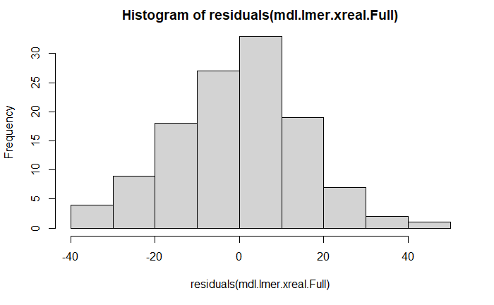

```r
hist(residuals(mdl.lmer.xreal.Full))
```

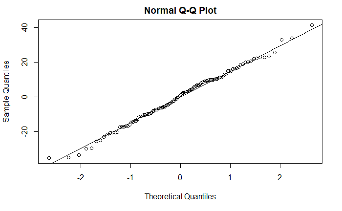

```r
qqnorm(residuals(mdl.lmer.xreal.Full)); qqline(residuals(mdl.lmer.xreal.Full))
```

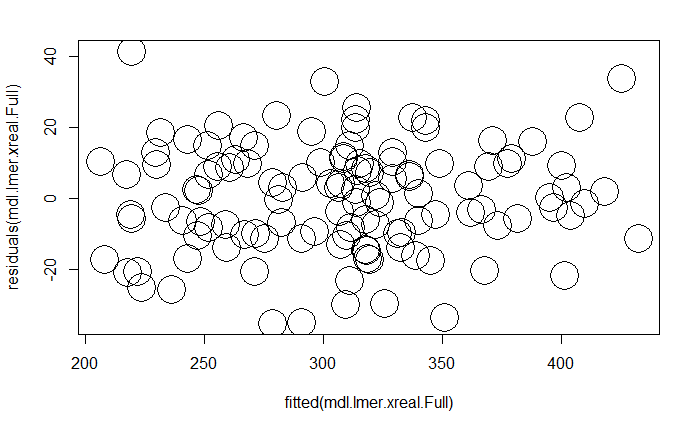

```r
plot(fitted(mdl.lmer.xreal.Full), residuals(mdl.lmer.xreal.Full), cex = 4)
```

## 6.7 Dissecting the model

```r
coef(mdl.lmer.xreal.Full)
```

```
$items
       (Intercept)   logFreq
Item1     352.3541 -5.460115
Item10    331.7629 -5.460115
Item11    324.7293 -5.460115
Item12    350.2297 -5.460115
Item13    353.1147 -5.460115
Item14    311.8401 -5.460115
Item15    354.0563 -5.460115
Item16    353.9361 -5.460115
Item17    288.7930 -5.460115
Item18    362.4659 -5.460115
Item19    338.1424 -5.460115
Item2     325.1878 -5.460115
Item20    359.7375 -5.460115
Item3     370.1747 -5.460115
Item4     302.4329 -5.460115
Item5     350.0478 -5.460115
Item6     338.9481 -5.460115
Item7     362.8357 -5.460115
Item8     295.6018 -5.460115
Item9     333.0702 -5.460115

$subjects
   (Intercept)   logFreq
S1    314.4719 -5.567204
S2    303.9072 -5.615345
S3    314.2944 -5.568013
S4    318.4301 -5.549168
S5    373.2970 -5.299153
S6    403.4376 -5.161809

attr(,"class")
[1] "coef.mer"
```

```r
fixef(mdl.lmer.xreal.Full)
```

```
(Intercept)     logFreq
 337.973044   -5.460115
```

```r
fixef(mdl.lmer.xreal.Full)[1]
```

```
(Intercept)
    337.973
```

```r
fixef(mdl.lmer.xreal.Full)[2]
```

```
  logFreq
-5.460115
```

```r
coef(mdl.lmer.xreal.Full)$`subjects`[1]
```

|  | (Intercept) |
| --- | --- |
| S1 | 314.4719 |
| S2 | 303.9072 |
| S3 | 314.2944 |
| S4 | 318.4301 |
| S5 | 373.2970 |
| S6 | 403.4376 |

```r
coef(mdl.lmer.xreal.Full)$`subjects`[2]
```

|  | logFreq |
| --- | --- |
| S1 | -5.567204 |
| S2 | -5.615345 |
| S3 | -5.568013 |
| S4 | -5.549168 |
| S5 | -5.299153 |
| S6 | -5.161809 |

```r
coef(mdl.lmer.xreal.Full)$`items`[1]
```

|  | (Intercept) |
| --- | --- |
| Item1 | 352.3541 |
| Item10 | 331.7629 |
| Item11 | 324.7293 |
| Item12 | 350.2297 |
| Item13 | 353.1147 |
| Item14 | 311.8401 |
| Item15 | 354.0563 |
| Item16 | 353.9361 |
| Item17 | 288.7930 |
| Item18 | 362.4659 |

[output cut: 10 more lines]

```r
coef(mdl.lmer.xreal.Full)$`items`[2]
```

|  | logFreq |
| --- | --- |
| Item1 | -5.460115 |
| Item10 | -5.460115 |
| Item11 | -5.460115 |
| Item12 | -5.460115 |
| Item13 | -5.460115 |
| Item14 | -5.460115 |
| Item15 | -5.460115 |
| Item16 | -5.460115 |
| Item17 | -5.460115 |
| Item18 | -5.460115 |

[output cut: 10 more lines]

```r
NA
```

## 6.8 Using predictions from our model

In general, I use the prediction from my final model in any plots. To generate this, we can use the following

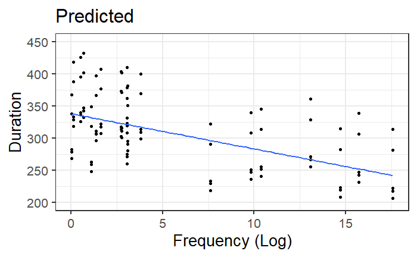

```r
xreal <- xreal %>%
  mutate(Pred_Dur = predict(mdl.lmer.xreal.Full))

xreal %>%
  ggplot(aes(x = logFreq, y = Pred_Dur)) +
  geom_point() + theme_bw(base_size = 20) +
  labs(y = "Duration", x = "Frequency (Log)", title = "Predicted") +
  geom_smooth(method = lm, se = F) + coord_cartesian(ylim = c(200,450))
```

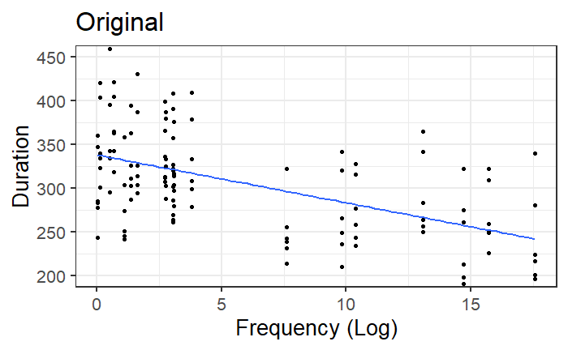

```r
## original plot
xreal %>%
  ggplot(aes(x = logFreq , y = dur)) +
  geom_point() + theme_bw(base_size = 20)+
  labs(y = "Duration", x = "Frequency (Log)", title = "Original")+
  geom_smooth(method = lm, se = F) + coord_cartesian(ylim = c(200,450))
```

## 6.9 GLMM and CLMM

The code above was using a Linear Mixed Effects Modelling. The outcome was a numeric object. In some cases (as we have seen above), we may have:

1. Binary outcome (binomial)
2. Count data (poisson),
3. Multi-category outcome (multinomial)
4. Rating data (cumulative function)

The code below gives you an idea of how to specify these models

```r
## Binomial family
## lme4::glmer(outcome~predictor(s)+(1|subject)+(1|items)..., data=data, family=binomial)

## Poisson family
## lme4::glmer(outcome~predictor(s)+(1|subject)+(1|items)..., data=data, family=poisson)

## Multinomial family
## a bit complicated as tehre is a need to use Bayesian approaches, see e.g.,
## glmmADMB
## mixcat
## MCMCglmm
## see https://gist.github.com/casallas/8263818

## Rating data, use following
## ordinal::clmm(outcome~predictor(s)+(1|subject)+(1|items)..., data=data)


## Remember to test for random effects and whether slopes are needed.
```